# Mobility

Marisangila Alves

10/26/2021

### Parâmetros

```
Parâmetros      | Valores
----------------------|----------
alfa zipf             | 0.8
lambda                | 5
n                     | 100
beta                  | 0.2
BS                    | 32
Cache                 | 100
UE                    | 200
Storage               | MBS 20GB SBS 4GB
Coverage              | MBS 300 SBS 70
RTT inicial           | CS/MBS 0.001s(1ms) MBS/MBS 0.001s(1ms) MBS/SBS 0.001s(1ms) SBS/UE 0.001s(1ms)
Tempo da Requisição   | 10 eventos
Mobilidade            | 2, 4, 6, 8, 10, 40, 70m
```

### Informações da Aplicação.

```
Vazão Mínima |     Tamanho da Cache        | Buffer |
-------------|-----------------------------|--------|
 100 Mbps    |      2GB/2000MB             |  48Mb  |
 100 Mbps    |      4GB/4000MB             |  48Mb  |
 100 Mbps    |      8GB/8000MB             |  48Mb  |
```

### Distribuição das Requisições.

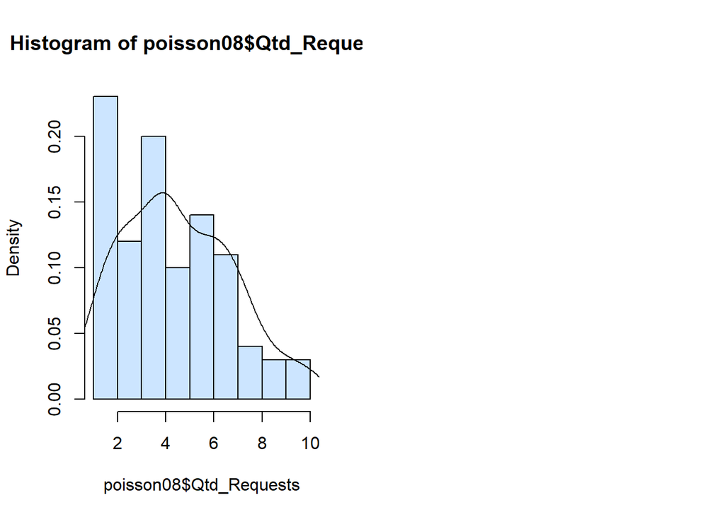

### Distribuição de popularidade do conteúdo solicitado.

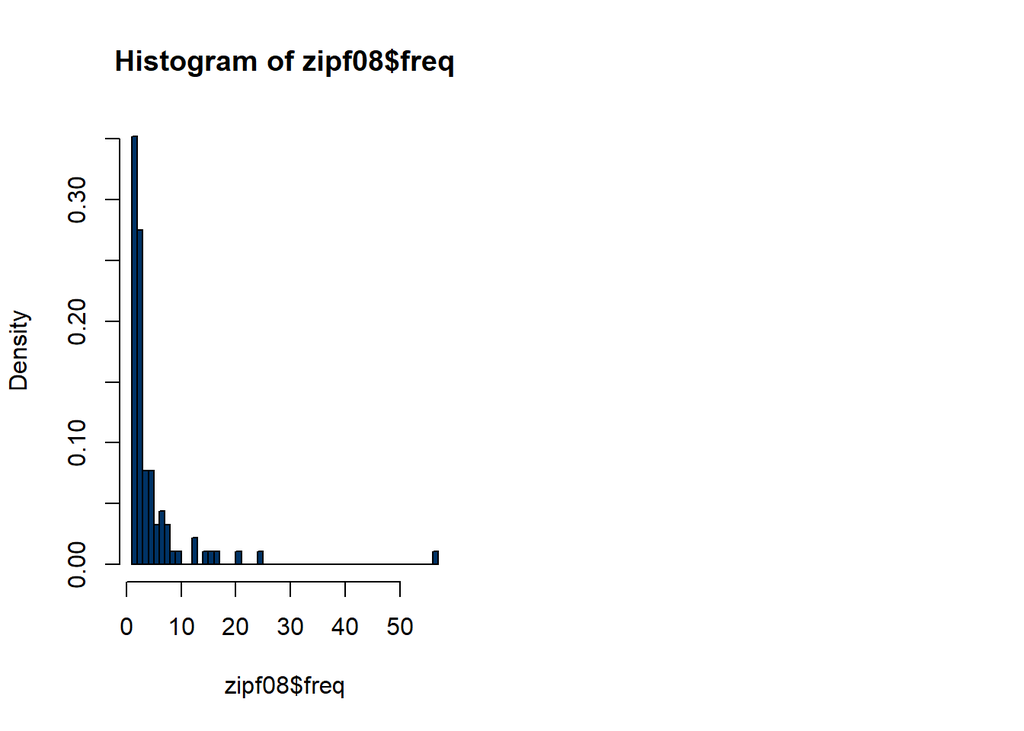

$\alpha : 2 =$ 100% - 454/454.

$\alpha : 5 =$ 100% - 454/454.

$\alpha : 8 =$ 100% - 454/454.

$\alpha : 10 =$ 100% - 454/454.

$\alpha : 40 =$ 100% - 454/454.

$\alpha : 70 =$ 100% - 454/454.

### Distribuição da Latência

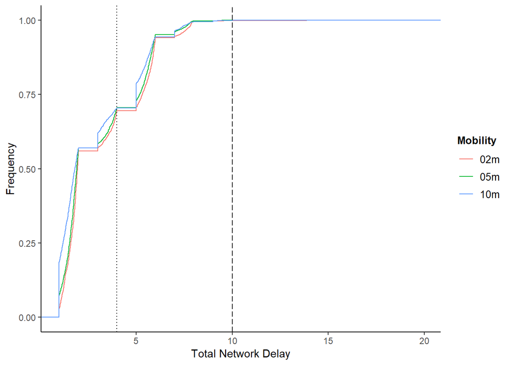

$Mobility$: $2$

Em $69.06\%$ da amostra a latência das requisições são menores que $4$ milisegundos.

Em $99.95\%$ da amostra a latência das requisições são menores que $10$ milisegundos.

$Mobility$: $4$

Em $70.32\%$ da amostra a latência das requisições são menores que $4$ milisegundos.

$Mobility$: $6$

Em $70.32\%$ da amostra a latência das requisições são menores que $4$ milisegundos.

Em $99.95\%$ da amostra a latência das requisições são menores que $10$ milisegundos.

$Mobility$: $8$

Em $70.32\%$ da amostra a latência das requisições são menores que $4$ milisegundos.

Em $99.95\%$ da amostra a latência das requisições são menores que $10$ milisegundos.

$Mobility$: $10$

Em $70.32\%$ da amostra a latência das requisições são menores que $4$ milisegundos.

Em $99.95\%$ da amostra a latência das requisições são menores que $10$ milisegundos.

$Mobility$: $40$

Em $70.32\%$ da amostra a latência das requisições são menores que $4$ milisegundos.

Em $99.95\%$ da amostra a latência das requisições são menores que $10$ milisegundos.

$Mobility$: $70$

Em $70.32\%$ da amostra a latência das requisições são menores que $4$ milisegundos.

Em $99.95\%$ da amostra a latência das requisições são menores que $10$ milisegundos.

### Cache, Cloud e Storage.

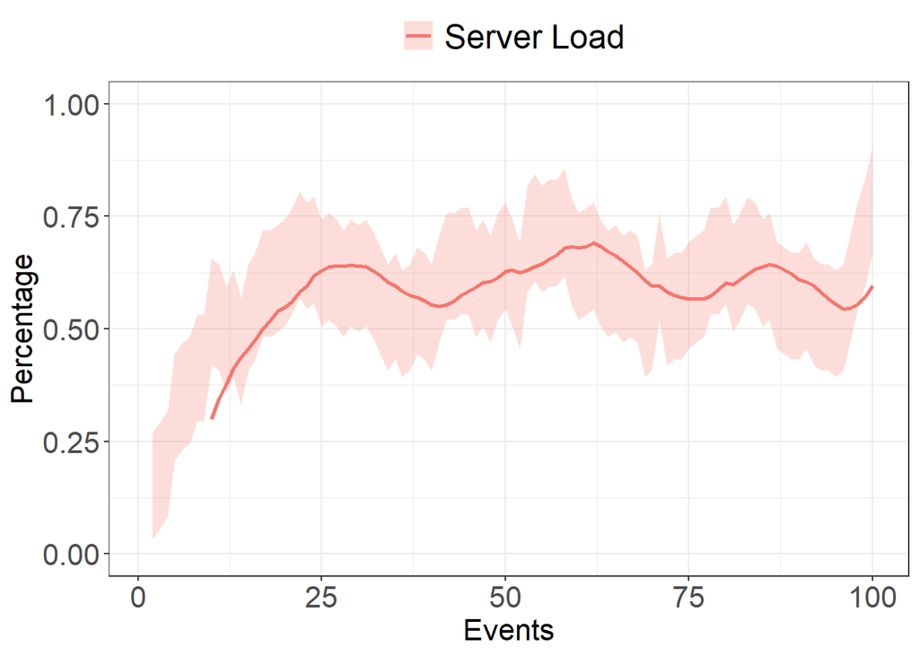

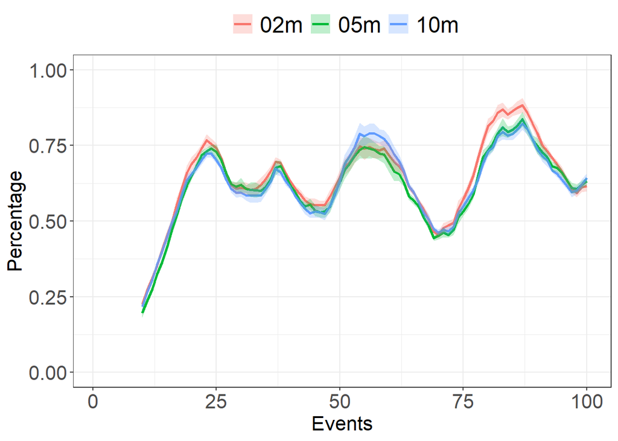

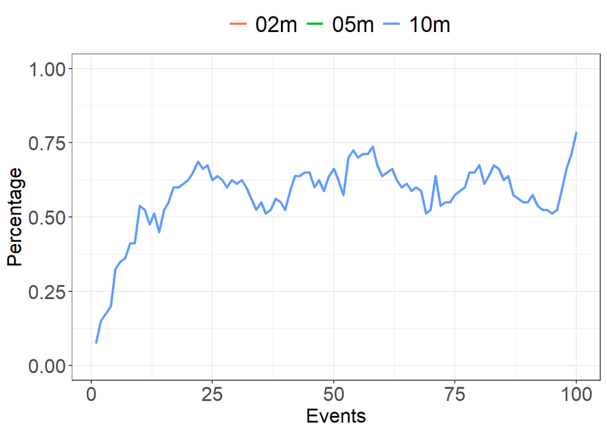

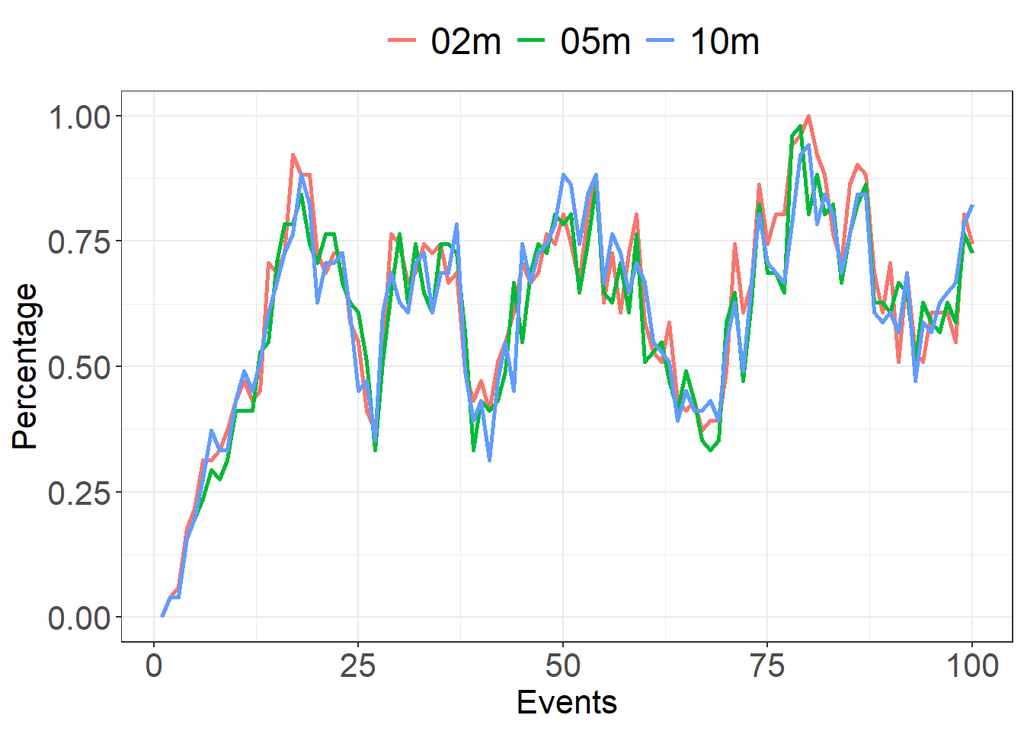

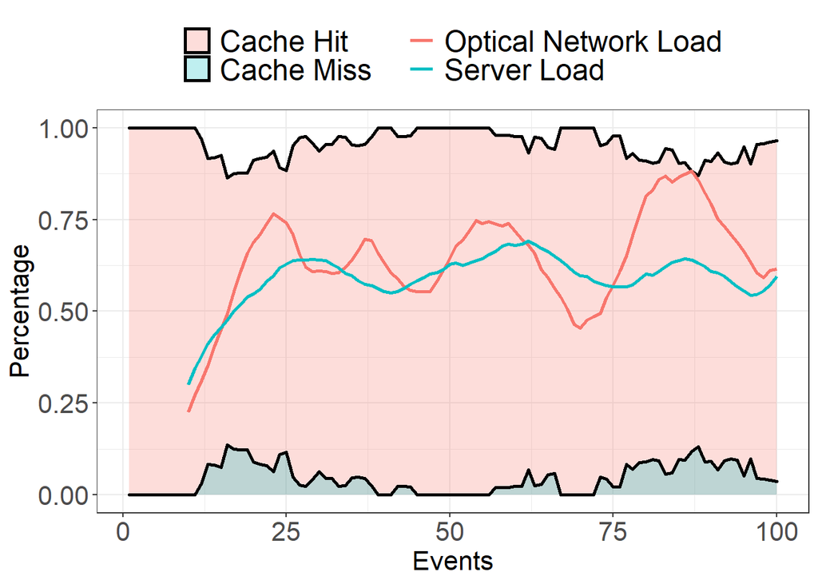

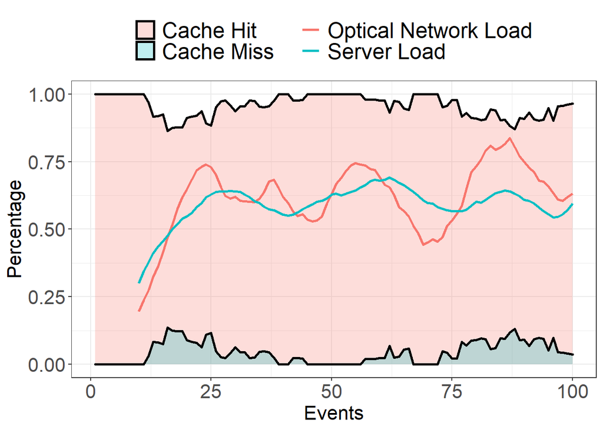

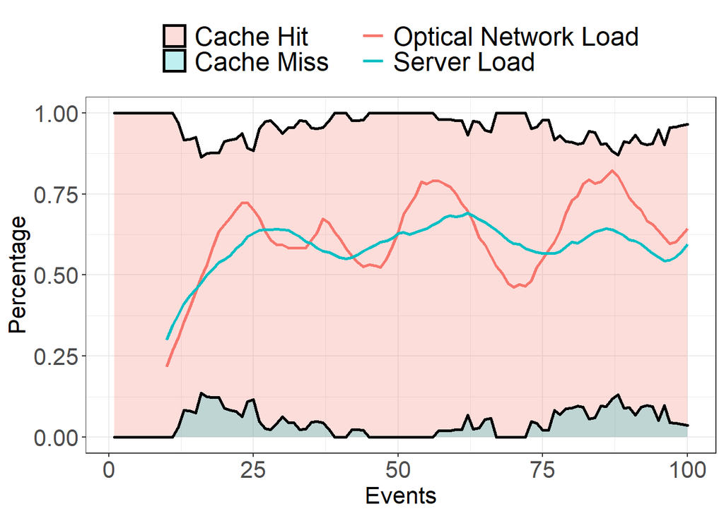

### Correlação entre as medianas da latência e variação da mobilidade.

```
## [1] -0.4493302
```

### Correlação entre taxas aceitação e variação da mobilidade.

```
## [1] NA
```

### Somatório da Carga dos enlaces ópticos por evento(normalizado pelo maior somatório).

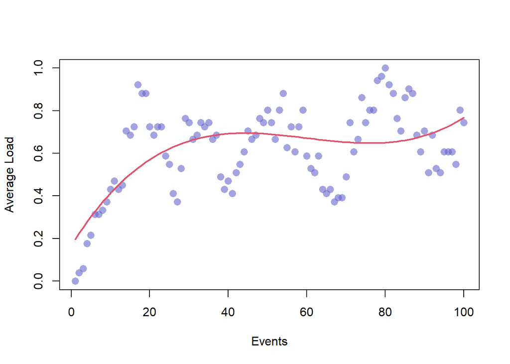

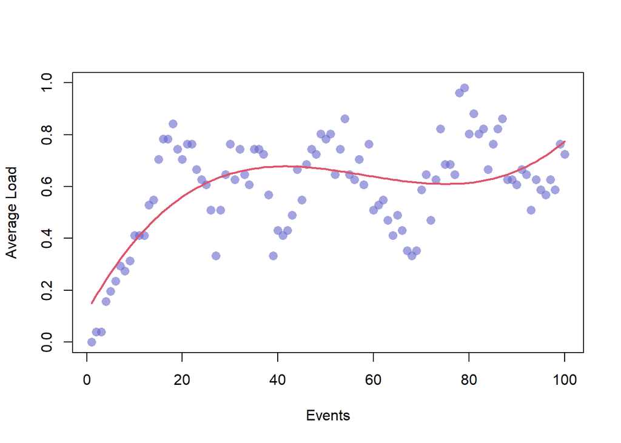

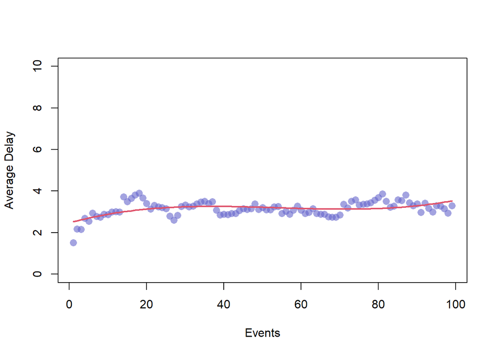

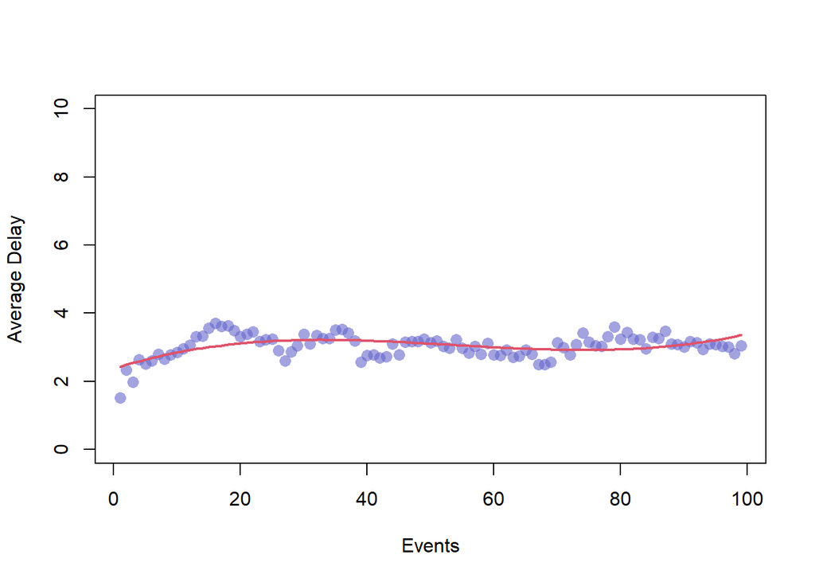

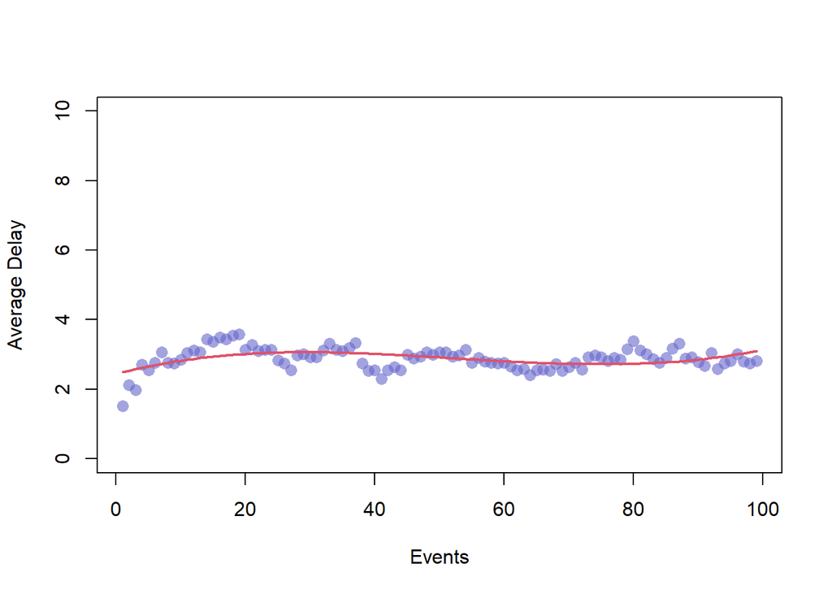